# Homework Problem

Laura Fürsich and Elic Weitzel

2022-06-29

```r
library(data.table)
library(dplyr)
library(igraph)
library(netdiffuseR)
```

# Question

**“An organization starts to encourage its employees to report when things go wrong”**

For an organization to succesfully implement changes following a report of an issue by an employee, there are many issues to overcome. One is the structure of the organization itself. Assuming only certain individuals in the organization are in a position to implement changes (i.e., the boss), it is necessary for the complaint to reach the boss’ ears before change can occur. However, organizations are not all structured in such a way as to promote complete and rapid information transfer to the top of the organization.

With this potential issue in mind, we investigated whether certain organizational structures were better than others for facilitating information transfer to the boss.

In particular, we focus with this paper on how network structures that differ in the degree to which they are hierarchical allow information to reach a central node. This approach provides insights on how different organizational structures facilitate the reports of malfunctioning or any issues arising in the organization.

# Approach

We use a networks-based approach to understand how information can reach the central node in a network depending on the degree to which a network is hierarchically structured.

To accomplish this objective, we conceptualized of an organization as a network of individuals, one of whom is the boss capable of implementing changes. To investigate the effect of different organizational (i.e., network) structure on information flow to the boss, we built several networks along a continuum of hierarchy and assume the CEO to be the most central node in the network.

At one extreme, we built a rigidly hierarchical network with the boss at the top of the hierarchy. Several middle managers run teams of employees and themselves report to the boss. The teams of employees report only to their immediate manager. All nodes in a team are connected to their immediate superior, who is also part of a team of three (middle management). One node in the middle management team is then connected to the CEO of the organization.

At the other extreme, we built a network that was non-hierarchical. A boss still exists, in the sense that only a single individual in the organization is capable of implementing changes, but the strict hierarchy of employee teams reporting to managers who report to the boss was no more. In this non-hierarchical network, connections between individuals of all job descriptions exist.

To simulate information transfer through these networks, we employed a contagion model approach implemented using the R package *netdiffuseR* and repeat the diffusion process 100 times with a maximum of 200 possible time steps to reach the CEO. The issue can be observed at any random node in the network.

## Model Assumptions

```r
NW_h_max = graph_from_literal(
  # LEVEL 1 ##############################
                       A1-B1, A1-C1, A1-D1,
                       B1-C1, B1-D1,
                       C1-D1,

                       E1-F1, E1-G1, E1-H1,
                       F1-G1, F1-H1,
                       G1-H1,

                       I1-J1, I1-K1, I1-L1,
                       J1-K1, J1-L1,
                       K1-L1,
   # LEVEL 2 ##############################
                       A2-B2, A2-C2,
                       B2-C2,

                       E2-F2, E2-G2,
                       F2-G2,

                       I2-J2, I2-K2,
                       J2-K2,
  # LEVEL 3 ##############################
                      # A3
# Connect across levels
  # LEVEL 1-2 ############################
                       A1-A2,B1-A2,C1-A2,D1-A2,
                       E1-E2,F1-E2,G1-E2,H1-E2,
                       I1-I2,J1-I2, K1-I2, L1-I2,

  # LEVEL 1-2 ############################
                       C2-A3, F2-A3, K2-A3
 )


#rewire graph to get minimum hierarchy

NW_h_min = erdos.renyi.game(22, 42, type = "gnm")


# rewire structured graph to get mean degree of clustering

NW_h_max <- get.adjacency(NW_h_max)

NW_h_mean = rewire_graph(NW_h_max,p=1, algorithm = "swap", pr.change=1)

n = 0

while (n<21){
  NW_h_mean = rewire_graph(NW_h_mean,p=1, algorithm = "swap", pr.change=1)
  n=n+1
}


#convert graphs to adjacency tables for netdiffuseR package
mingraph <- get.adjacency(NW_h_min)
meangraph <- NW_h_mean
maxgraph <- NW_h_max
```

## Complaint Contagion Dynamics

Using the *rdiffnet()* function from the *netdiffuseR* package, we randomly assigned one of the nodes in the network a complaint. A simulation was then run for 200 time steps in which that complaint could be taken up by connected nodes with a probability of 0.50. We then calculated how many time steps it took for the complaint to reach the boss, assuming that at that point, a change could then be implemented.

We replicated this process 100 times with a different node chosen randomly each time as the origin of the complaint, tracking the number of time steps needed for the boss to hear the complaint each time.

```r
#define the function to be replicated
replgraph <- function(graph, nodes, timesteps, p.adoption){
  seed.p.adpt <- 1/nodes
  diffnet_output <- rdiffnet(nodes, timesteps, seed.nodes = "random",
                             seed.p.adopt = seed.p.adpt,
                             seed.graph = graph,
                             threshold.dist = p.adoption)
  bossknows <- diffnet_output$toa[22]
}

#replicate the function
set.seed(12345)
minresults <- try(replicate(100, try(replgraph(mingraph, 22, 200, 0.5))))

set.seed(12345)
meanresults <- try(replicate(100, try(replgraph(meangraph, 22, 200, 0.5))))
```

```
## Error in rdiffnet(nodes, timesteps, seed.nodes = "random", seed.p.adopt = seed.p.adpt,  :
##   No diffusion in this network (Ups!) try changing the seed or the parameters.
```

```r
set.seed(12345)
maxresults <- try(replicate(100, try(replgraph(maxgraph, 22, 200, 0.5))))

#convert the results to a numeric vector
minresults <- as.numeric(minresults)
meanresults <- as.numeric(meanresults)
maxresults <- as.numeric(maxresults)
```

# Results

In the minimally hierarchical network, the complaint reached the boss in an average of 41.48 and a median of 33.5 time steps. In the moderately hierarchical network, the boss learned of the issue in only 45.67 time steps on average, or a median of 35. In the most hierarchical network, these times are similar with a mean of 49.37 and a median of 42.

Our results do not indicate that there is any difference in information transfer speed through a network given the hierarchical structure of the network. While small differences exist between networks of different hierarchy, these differences do not appear to be meaningful and are not consistent across simulations.

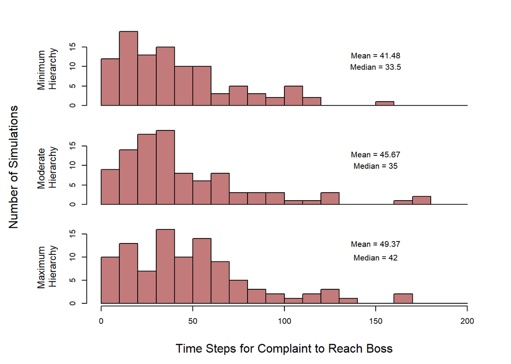

```r
par(mfrow=c(3, 1), mar=c(1, 1, 1, 1), oma = c(5, 8, 2, 2))
hist(minresults, breaks = seq(0, 200, by = 10), main = "", xlab = "", axes = F, col = "#8B000085")
axis(2)
mtext("Minimum \nHierarchy", side = 2, line = 3, cex = 0.8)
text(150, 13, paste("Mean =", round(mean(minresults, na.rm = T), 2)))
text(150, 10, paste("Median =", round(median(minresults, na.rm = T), 2)))
hist(meanresults, breaks = seq(0, 200, by = 10),  main = "", xlab = "", axes = F, col = "#8B000085", border = T)
axis(2)
mtext("Moderate \nHierarchy", side = 2, line = 3, cex = 0.8)
mtext("Number of Simulations", side = 2, line = 7)
text(150, 13, paste("Mean =", round(mean(meanresults, na.rm = T), 2)))
text(150, 10, paste("Median =", round(median(meanresults, na.rm = T), 2)))
hist(maxresults, breaks = seq(0, 200, by = 10),  main = "", axes = F, col = "#8B000085")
axis(2)
axis(1)
mtext("Maximum \nHierarchy", side = 2, line = 3, cex = 0.8)
text(150, 13, paste("Mean =", round(mean(maxresults, na.rm = T), 2)))
text(150, 10, paste("Median =", round(median(maxresults, na.rm = T), 2)))
mtext("Time Steps for Complaint to Reach Boss", side = 1, line = 4)
```

# Conclusions

Our analysis suggests that organizational structure has no impact on the speed of information transfer. The number of time steps for a complaint to reach the boss in our model is broadly consistent, whether the network is hierarchical or non-hierarchical.

## Potential Shortcomings

However, the reason for this may be the small size of the networks we modeled. With only a small number of nodes and edges, hierarchical structure may not substantially impact information transfer through the network. But if we scaled up our networks, this result may no longer hold. This would likely be a fruitful avenue for future research.

## Further Directions

We identify several potential future directions to further this project. First, we suggest expanding the variation in network hierarchy to understand in more detail at which point information is reliably reaching the CEO while maintaining a hierarchical organizational structure. In other words, this setup allows us to explore a potential tipping point behavior in the system. Careful Agent-Based Modelling could provide insight to where the success decreases dramatically (e.g., Schelling, 1971), providing insights regarding the minimal level of interconnectivity of agents required to facilitate the flow of information.

Related, but distinct from tipping points are Threshold models (Granovetter, 1978), similar to protest movements such as e.g., the Arab Spring or the Monday Protests in the GDR. We consider this the second potential direction for this paper. In particular, we suggest that each actor could potentially have an individual threshold of connected actors who need to agree on a potential issue for it to be worth it reporting. Only if the threshold is high enough, the individual actor will decide to report.

## Application

Information cascades are relevant in various social science fields. One real world phenomenon that has interesting overlap with our above presented approach are the dynamics of reports brought forward during the #metoo movement. Popular news outlets such as the New Yorker describe the process of allegation against Harvey Weinstein as follows:

*“The allegations set off a movement whose impact few could have imagined. On October 15th, the actress Alyssa Milano tweeted, “If you’ve been sexually harassed or assaulted write ‘me too’ as a reply to this tweet.” Seventeen thousand women would ultimately respond—effectively joining a “me too” movement that had been founded a decade earlier, by the activist Tarana Burke. By the end of October, more than eighty women had claimed that Weinstein had sexually assaulted them, a figure that would eventually rise to more than a hundred.”*

Ken Auletta, Harvey Weinstein’s Last Campaign. The New Yorker, May 30, 2022.

In order to model such phenomena, we would require some adjustments to the above-described approach. In particular, we would have to carefully model the individual actors’ network environment. In addition, previous applications of threshold models suggest that threshold vary between individuals. This model would allow us to understand why for years allegations against Harvey Weinstein did not arrive at a central node in the network that can implement change. One possible contributor to the eventual lawsuit could be increase connectivity amongst victims, allow for the information cascade to process and information to reach crucial nodes in the network.

# References

Granovetter, M. Threshold Models of Collective Behavior. *American Journal of Sociology*, 83, 1420–1443 (1978).

Schelling, T. C. (1971). Dynamic models of segregation. *Journal of Mathematical Sociology*, 1(2), 143-186.